# Notes FSML II

#### The Maximum Likelihood

**Def:** likelihood

Let $X_1, ..., X_n$ independent random variables, whose distributions are all depending on the same parameter $\Theta$.

Let $x_1, ..., x_n$ observations of those r.v

**Def:** Estimator thanks to the maximum likelihood.

$\hat{\Theta}_n$, an estimator for $\Theta$, due to the maximum likelihood, is solution of:

$$\mathcal{L}(x_1, ..., x_n, \Theta) = \max_{\theta} \mathcal{L}(x_1, ..., x_n, \Theta)$$

*Applications*

Let consider $X_1, ..., X_n$ $\xi(\lambda)$ *i.i.d*.

Compute the maximum likelihood estimator.

Solution:

```r
n= 100

U = runif(n, 0, 4)

theta = max(U)


for (i in 1:50) {
  U = runif(n, 0, 4)
  theta = c(theta, max(U))
}


mean(theta)
```

```
## [1] 3.968432
```

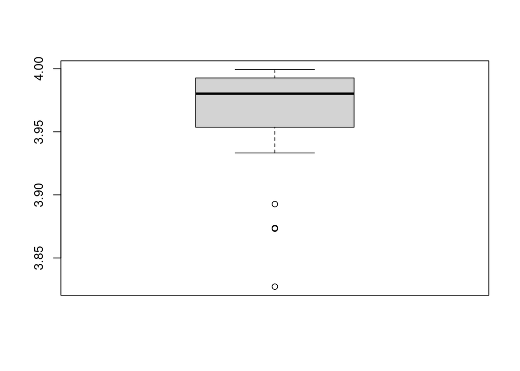

```r
boxplot(theta)
```

```r
## Adjust to make the estimator unbiased

thetab = (n+1)/n*theta

mean(thetab)
```

```
## [1] 4.008116
```

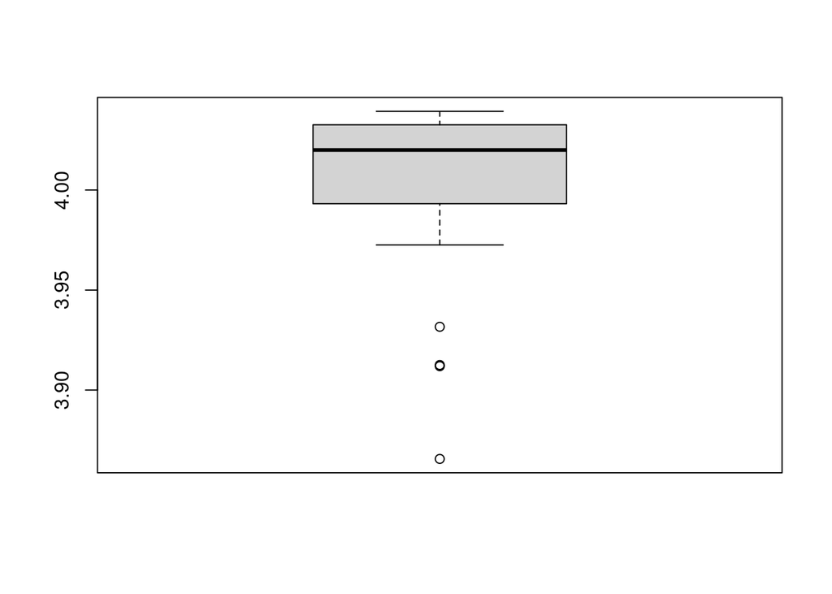

```r
boxplot(thetab)
```

```r
## With more observations

n= 100

U = runif(n, 0, 4)

theta = max(U)


for (i in 1:5000) {
  U = runif(n, 0, 4)
  theta = c(theta, max(U))
}


mean(theta)
```

```
## [1] 3.960392
```

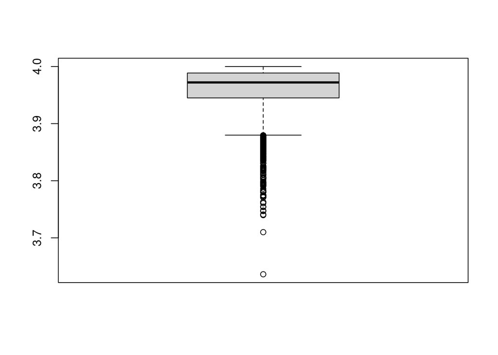

```r
boxplot(theta)
```

**Property**

Let $X_1, ..., X_n$ *i.i.d* r.v. Let $\mu = \mathbb{E}[X_1]$ (unknown) Let $\sigma^2 = V(X_1)$ (unknown)

A classical estimator is:

- $\mu$ is $\hat{\mu}_n = \overline{X}_n = \frac{1}{n} \sum X_i$
- $\sigma^2$ is $\hat{\sigma}^2_n = \frac{1}{n} \sum (X_i - \overline{X}_n)^2$

**Exercise**

Show that:

1. $\hat{\mu}$ is unbiased.
2. $\hat{\sigma}^2_n$ is biased and that $\dfrac{n}{n-1}\hat{\sigma}^2_n$ is unbiased.